# Assignment12

Morgann Plante

10/19/2020

*How to do it?*:

- Open the Rmarkdown file of this assignment (link) in Rstudio.
- Right under each **question**, insert a code chunk (you can use the hotkey `Ctrl + Alt + I` to add a code chunk) and code the solution for the question.
- `Knit` the rmarkdown file (hotkey: `Ctrl + Alt + K`) to export an html.
- Publish the html file to your Githiub Page.

*Submission*: Submit the link on Github of the assignment to Blackboard.

1. Install the package `mlbench` and use the follows to import the data

```r
library(tidyverse)
library(caret)
library(rpart)
library(mlbench)
data(PimaIndiansDiabetes)
df <- PimaIndiansDiabetes
```

- Set seed to be 2020.
- Partition the data into 80% training and 20% testing.

```r
library(caret)
set.seed(2020)
splitIndex <- createDataPartition(df$diabetes , p = .80,
                                  list = FALSE)
df_train <- df[ splitIndex,]
df_test <- df[-splitIndex,]
```

2. Use cross-validation of 30 folds to tune random forest (method=‘rf’). What is the `mtry` value that produces the greatest accuracy?

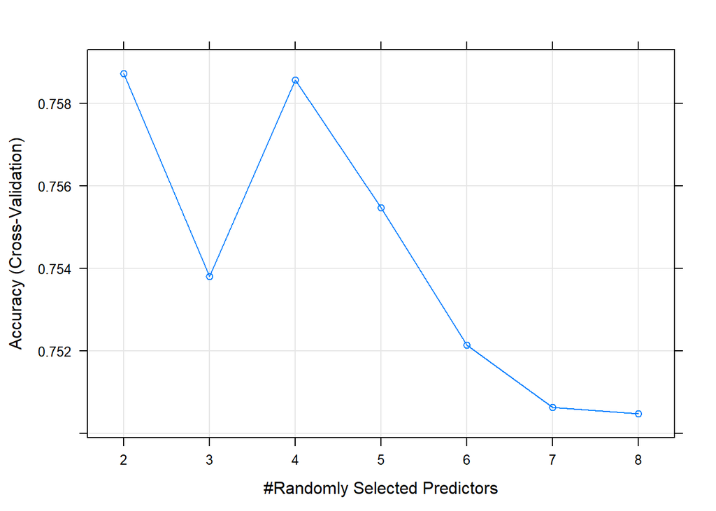

```r
tuneGrid = expand.grid(mtry = 2:8)
trControl = trainControl(method = "cv",
                         number = 30)
forest_cv <- train(diabetes~., data=df_train,
                                method = "rf",
                                trControl = trControl,
                                tuneGrid = tuneGrid)
plot(forest_cv)
```

```r
print(forest_cv)
```

```
## Random Forest
##
## 615 samples
##   8 predictor
##   2 classes: 'neg', 'pos'
##
## No pre-processing
## Resampling: Cross-Validated (30 fold)
## Summary of sample sizes: 594, 594, 594, 594, 594, 594, ...
## Resampling results across tuning parameters:
##
##   mtry  Accuracy   Kappa
##   2     0.7587302  0.4513576
##   3     0.7538095  0.4438257
##   4     0.7585714  0.4534082
##   5     0.7554762  0.4457299
##   6     0.7521429  0.4382917
##   7     0.7506349  0.4388798
##   8     0.7504762  0.4376018
##
## Accuracy was used to select the optimal model using the largest value.
## The final value used for the model was mtry = 2.
```

3. Use cross-validation with of 30 folds to tune random forest (method=‘ranger’). What are the parameters that produce the greatest accuracy?

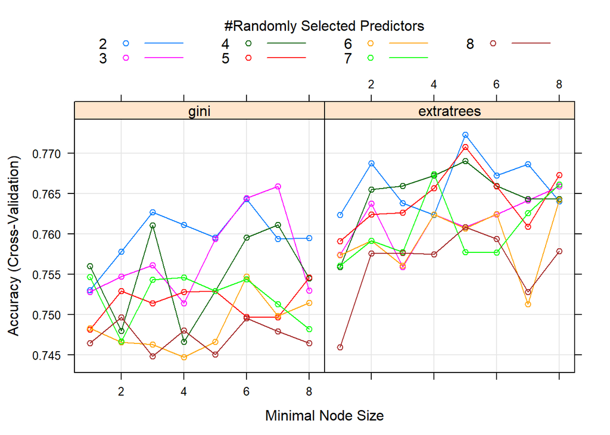

```r
trControl = trainControl(method = "cv",
                         number = 30)
tuneGrid = expand.grid(mtry = 2:8,
                       splitrule = c('gini', 'extratrees'),
                       min.node.size = c(1:8))
ranger_cv <- train(diabetes~., data=df_train,
                    method = "ranger",
                    trControl = trControl,
                    tuneGrid = tuneGrid)
plot(ranger_cv)
```

4. Go to https://topepo.github.io/caret/available-models.html and pick a classification model. Tune the classification model using cross-validation of 30 folds.

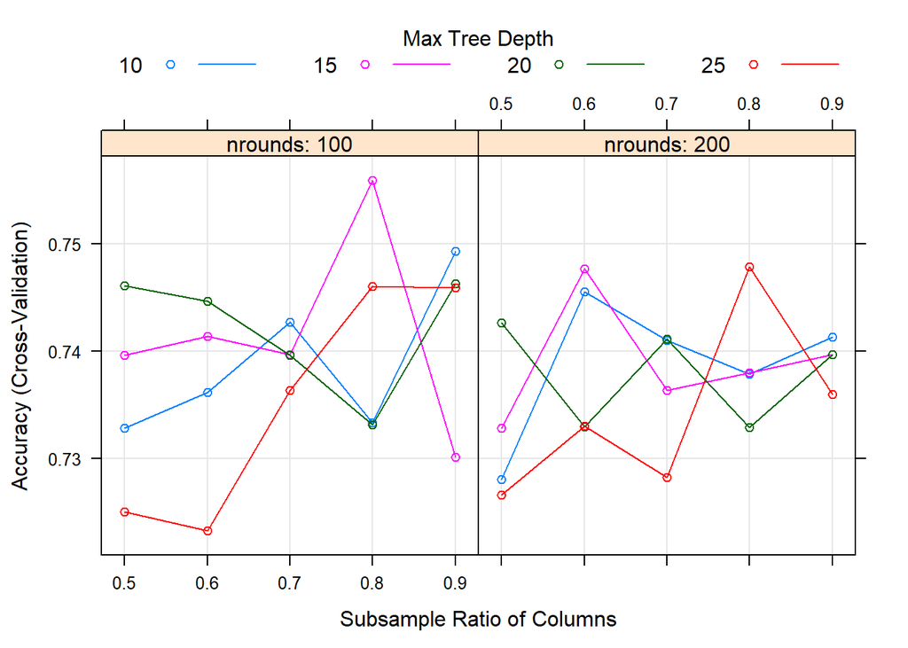

```r
library(readxl)
library(tidyverse)
library(xgboost)

X_train = xgb.DMatrix(as.matrix(df_train %>% select(-diabetes)))
y_train = df_train$diabetes

xgb_trcontrol = trainControl(
  method = "cv",
  number = 30,
  allowParallel = TRUE,
  verboseIter = FALSE,
  returnData = FALSE
)

xgbGrid <- expand.grid(nrounds = c(100,200),
                       max_depth = c(10, 15, 20, 25),
                       colsample_bytree = seq(0.5, 0.9, length.out = 5),
                       eta = 0.1,
                       gamma=0,
                       min_child_weight = 1,
                       subsample = 1
                      )
set.seed(0)
xgb_model = train(
  X_train, y_train,
  trControl = xgb_trcontrol,
  tuneGrid = xgbGrid,
  method = "xgbTree"
)
plot(xgb_model)
```

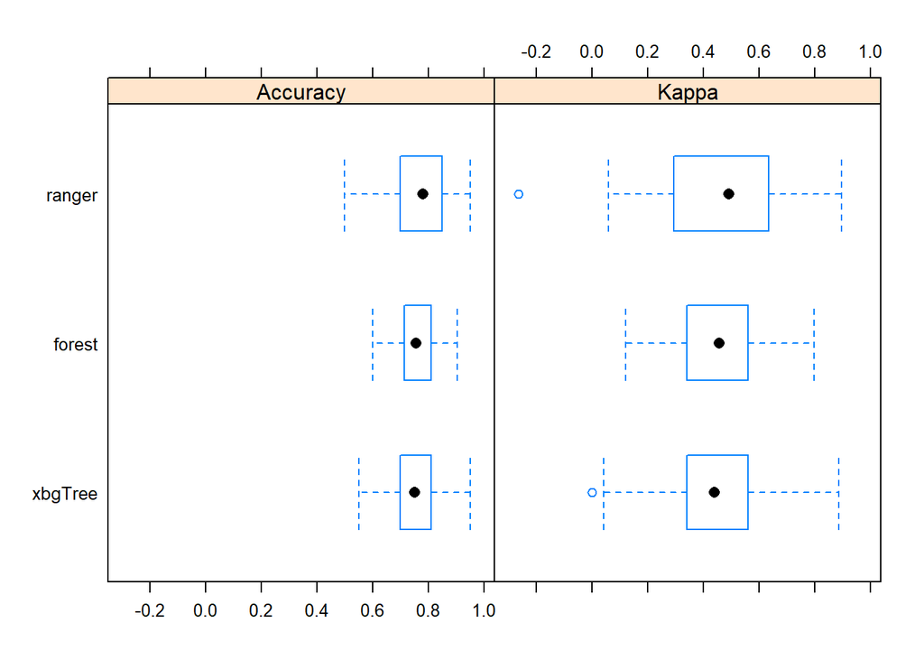

```r
results <- resamples(list(forest = forest_cv,
                          ranger = ranger_cv,
                          xbgTree= xgb_model))
bwplot(results)
```